# What Factors Impact China's Economy？

### Introduction

Since 2012, the anti-corruption campaign under Xi Jinping, General Secretary of the Chinese Communist Party (CCP), was the greatest organized anti-graft effort in China's history of CCP rule. This project is based on How Corruption Undermine Regime Support, Evidence from China, written by Yuhua Wang and Bruce J. Dickson (Wang&Dickson, 2020), and delves into the 2012 to 2016 anti-corruption campaign's effect on economic performance in China.

This project will wrangle multiple raw datasets and merge them into a completely clean dataset. Then this project will apply statistical learning processes to assess the relationship between economic performance and the corruption investigation by conducting a linear regression model and a model tuning pipeline to assess by including more variables that are possibly related to economic performance.

This project aims to provide a statistical outlook of China's anti-corruption under Xi and explains its relationship with China's performance legitimacy through the economic pillar.

### Background

Authoritarian leaders seek to win public support through intensive corruption investigations, strengthening their legitimacy. As an authoritarian regime, the Chinese government lacks confidence in legitimacy because of the lack of universal suffrage, while escalated internal tensions within elites and declining trust and loyalty among the population are hard to track when the regime provides limited access for public opinion expression (du Boulay, 2019). CCP considered economic performance as one essential element in strengthening legitimacy. Under Roskin's statement, China's regime retains authority by means of patriotism and performance-based legitimacy, which reflects policy focused on ensuring economic growth, providing social stability, and defending national sovereignty (Roskin, 2016). For Chinese leaders, fighting corruption along with fighting poverty and unemployment is considered an approach of making promises garnering public support, signaling their responsiveness and benevolent intentions to the public, making anti-corruption efforts an agenda of successive (Wang&Dickson, 2020).

Since Xi Jinping took power in both CCP and the Chinese government in 2012, the party launched an anti-corruption campaign, aiming to eliminate "tigers" (high-ranking corrupt officials) and "flies" (low-ranking corrupt officials) (Wang&Dickson, 2020). Starting with the first salvos which sack of Sichuan Deputy Party Secretary Li Chuncheng at the end of 2012, the corruption campaign reached its peak at the third quarter in 2014, with the fall of the "Four Big Tigers": General Xu Caihou, Su Rong, Zhou Yongkang, and Ling Jihua ( Zuo, 2014). While investigations on the four top-ranking officials are mainly focused on their corruption and bribery incidents during their term in local government, those investigations have caused investigations on officials who served alongside with them, leading to an increasing number of investigations from 2014 to 2015 (Luo, 2015). The campaign was mainly executed under the Central Commission for Discipline Inspection (CCDI) from 2012 to 2017 and is likely to continue in the long term and reach other peaks in the future (Barreda, Jakes, Laha, & Segal-Williams, 2018).

However, it is arguable that removing a large number of officials causes backfires with increasing political uncertainty and harming economic performance, and hurting legitimacy. China's political features explain that the anti-corruption campaign creates power vacuums and leads to political discontinuity. Under the party-state system, the political institutions functionally intertwine with the CCP and government. The political institution of the party controls the supreme power, while the government is responsible for executing the decision made by the party (Li, 2010). The policy implementation process is top-down in reality. Thus, theoretically, removing officials from higher levels creates power vacuums, leaving no one to take accountability for already implemented policies.

On the other hand, corruption investigation can stimulate officials to accomplish economic goals. Under the hierarchic administrative system with the party making supreme decisions, the local government's credits are heavily based on completing tasks by higher-ranked political apparatuses. In terms of related economic policies, China's key bureaucracies are partially centralized in order to regulate and discipline local government agents in their management of the economy and the implementation of policy more generally (Mertha, 2005). Removing lower-ranked officials forced remaining officials to be concerned that they would be the next to be investigated if they failed to accomplish policy goals, forcing them to be more progressive.

This project will be analyzing whether removing officials at all levels of government during the anti-corruption campaign will influence the economic performance at the provincial level in the short run and whether the influence was positive or negative. Moreover, this project will look at the provincial economic performance, in the long run, considering factors other than the 2012-2016 anti-corruption campaign.

### Data

This project uses China's Corruption Investigations Dataset collected by Yuhua Wang in 2020. China's Corruption Investigations Dataset includes information on almost 20,000 officials investigated during Xi's anti-corruption campaign from 2012 to 2016, including each official's name, position, locality, rank, and reason for investigations. Wang collects the data from Tencent, the largest Internet company in China, by scraping Tencent's website and organizing the database in an analysis-ready format. This project will mainly focus on Year, locality, rank for investigations. Specifically, the variable of Year indicates the Year of the announcement of the investigation, which is the Year of the closing file of the corruption case. Furthermore, the rank variable includes an official's rank ranging from 1 to 10, where 1 indicates the highest rank state level,10 as lowest rank, deputy office level. In addition, the locality of investigations is presented as mainland land China county name, along with 6-digit county number, 6-digit prefecture number, and 6-digit province number.

For the long run research, this project includes some possible variables related to annual GRP, including the number of industrial enterprises above designated size, average wage of employed persons in urban units, local governments general budgetary expenditure, end-of-year regional resident population, the population density of urban area, urban area of the province, number of employed persons in urban units, unemployment rate in urban area, and number of cities at prefecture level and above. All data mentioned above are collected by NBS of China at the provincial level, while some are collected up to date (to 2020).

**The number of industrial enterprises above designated size** is state-owned and non-state-owned enterprises with annual revenue from principal businesses over 5 million yuan. Average wage of employed persons in urban units refers to the average per capita.

**Average wage of employed persons in urban units** refers to the average per capita wage during a certain period for employed persons, indicating the general level of wage income of staff and workers during a certain period. This variable is calculated in the current RMB yuan.

**Local governments general budgetary expenditure** includes expenditures made by the local government for general public services, public security, education, science and technology, culture, sport and media, social safety net and employment effort, health care, environmental protection, urban and rural community affairs, agriculture, forestry and water conservancy, transportation and other expenditures. This variable is calculated in the unit of 100 million current yuan.

**End-of-year regional resident populations** are estimated based on the annual national sample surveys on population changes and are permanent resident populations since 2005. This variable is collected in the unit of 10000 persons.

**Urban area of the province** is the area of the city in the given province proper before 2006, which is collected in sq.km.

**Population density of urban areas** is calculated by dividing the total population by urban area, with the unit of person/sq.km.

**Number of employed persons in urban units** is estimated according to the Labour Force Survey and Population Census and is revised according to the 6th National Population Census. This variable is collected in the unit of 10000 persons. Unemployment rate in urban areas is calculated as a percentage out of the total residence population.

**The number of cities at prefecture level** is more convincing for provinces and autonomous regions. Four direct-administered municipalities, Beijing, Shanghai, Tianjin, and Chongqing, are the highest level of classification for cities and have the same rank as provinces and form part of the first tier of administrative divisions of China (State Council of the People's Republic of China, 2014). Thus The number of cities at the prefecture-level for the four municipalities is 1.

All raw datasets can be accessed directly through web downloading; however, the final version of the data applied in the analysis is wrangled on presentations of variables and the table layout. The data wrangling process is accomplished in python 3.

The number of investigations each year by province (the number of officials being removed), which is a primary independent variable this project will be mainly looking at, is not listed directly in the raw dataset. Thus, we filtered out variables, province, year, and name of officials, grouped them by officials' names and counted the number of observations using the size method. After doing this process, we used .replace to convert the province code to Pinyin romanization system according to Codes for the Administrative Divisions of the People's Republic of China released by the Standardization Administration of China (which is exactly the same as the "Region" variable in datasets from NBS of China) (Standardization Administration of China, 2021). We further found several cases recorded without a specific year and are denoted as ".". Thus, we removed these missing data lines.

For other datasets from NBS of China, we merged them and the corruption data frame we got in the previous step, specifically on variables of "Region" and "Year". Since some of the NBS variables are collected from 2011 to 2019, and the corruption data frame ranges from 2012 to 2016, we dropped data from 2011, 2017, 2018, 2019, and 2020.

|  | province | Year | Gross Product | Number of Industrial Enterprises | Average Wage | Budgetary Expenditure | Population_Density | Urban Area | Number of Cities | Unemployment Rate | Population | Number of Employed Population | Number of Cases |
| --- | --- | --- | --- | --- | --- | --- | --- | --- | --- | --- | --- | --- | --- |
| 0 | Beijing | 2016 | 27041.2 | 3340.0 | 119928.0 | 6406.77 | 1145.0 | 16410.0 | 1.0 | 1.4 | 2195 | 791.5 | 5.0 |
| 1 | Tianjin | 2016 | 11477.2 | 5203.0 | 86305.0 | 3699.43 | 3639.0 | 2583.0 | 1.0 | 3.5 | 1443 | 286.0 | 1.0 |
| 2 | Hebei | 2016 | 28474.1 | 14764.0 | 55334.0 | 6049.53 | 2659.0 | 6613.0 | 11.0 | 3.7 | 7375 | 639.6 | 2.0 |
| 3 | Shanxi | 2016 | 11946.4 | 3548.0 | 53705.0 | 3428.86 | 3908.0 | 2893.0 | 11.0 | 3.5 | 3514 | 430.6 | 2.0 |
| 4 | Inner Mongolia | 2016 | 13789.3 | 4289.0 | 61067.0 | 4512.71 | 1822.0 | 4872.0 | 9.0 | 3.6 | 2436 | 293.2 | 11.0 |
| ... | ... | ... | ... | ... | ... | ... | ... | ... | ... | ... | ... | ... | ... |
| 150 | Shaanxi | 2012 | 14142.4 | 4284.0 | 43073.0 | 3323.80 | 5483.0 | 1504.0 | 10.0 | 3.2 | 3787 | 411.2 | 1.0 |
| 151 | Gansu | 2012 | 5393.1 | 1735.0 | 37679.0 | 2059.56 | 4369.0 | 1292.0 | 12.0 | 2.7 | 2550 | 211.3 | 1.0 |
| 152 | Qinghai | 2012 | 1528.5 | 423.0 | 46483.0 | 1159.05 | 2674.0 | 512.0 | 1.0 | 3.4 | 571 | 61.7 | 0.0 |
| 153 | Ningxia | 2012 | 2131.0 | 865.0 | 47436.0 | 864.36 | 1251.0 | 2103.0 | 5.0 | 4.2 | 659 | 67.4 | 0.0 |
| 154 | Xinjiang | 2012 | 7411.8 | 1959.0 | 44576.0 | 2720.07 | 4312.0 | 1559.0 | 2.0 | 3.4 | 2253 | 288.8 | 1.0 |

155 rows × 13 columns

### Analysis

As discussed above, this project will be analyzing both short-term and long-term effects of investigations on the gross regional product. Specifically, the short-run effect will be analyzed by conducting a linear regression model, while the long-run effect will be predicted by conducting hyper-parameter tuning and model comparison.

By completing data cleaning and wrangling, we can better visualize the basic summary statistics of our data. As presented in Pair Plot for Ranks of Officials Invested Each Year, we see a higher number of officials from a lower rank are incited from 2012 to 2016, with an increasing number from 2012, and reached a peak in 2015.

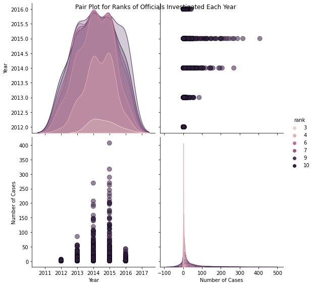

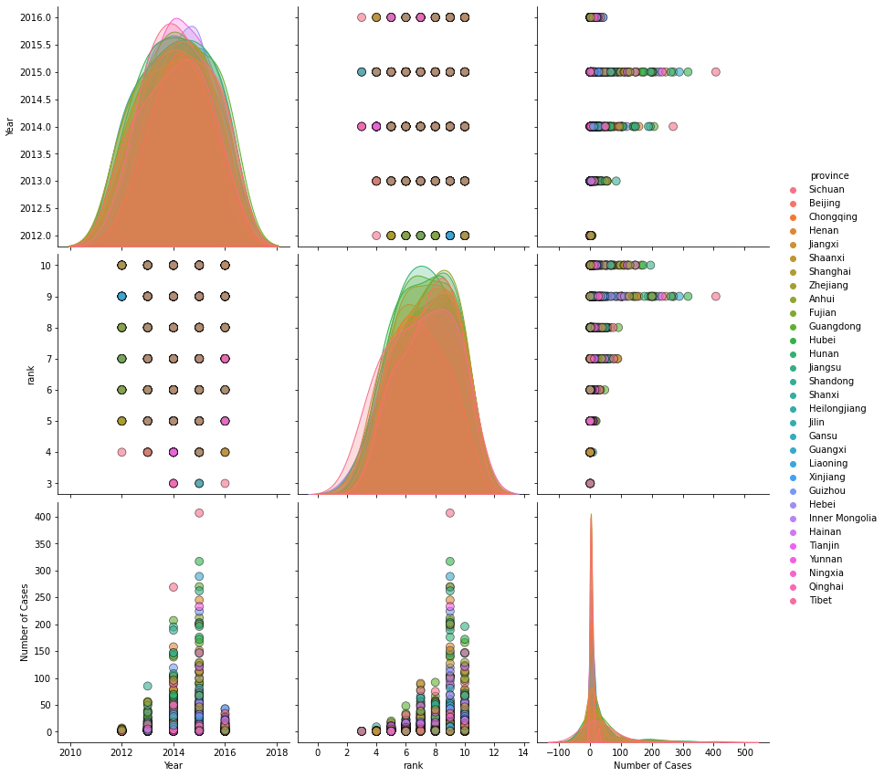

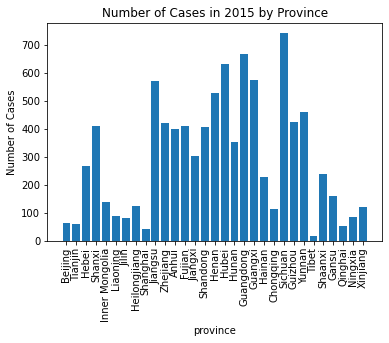

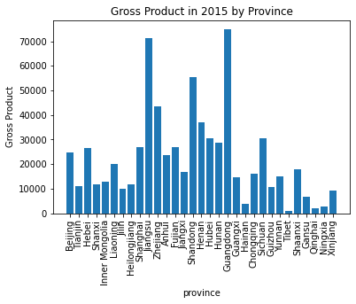

The geoplots provide patterns of the geographic distribution of investigations and GRP in 2015. The Southwest, Central South, East, and Southeast China provinces have higher number of investigations than the rest of the provinces. At the same time, the GRP geoplot also shows this pattern, with East and Southeast China provinces having greater annual GRP.

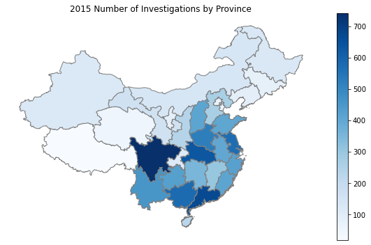

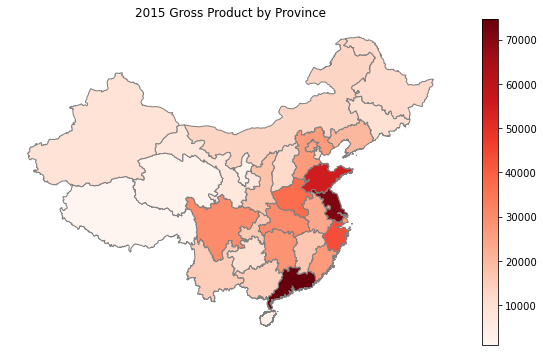

Based on the preliminary analysis, we use design matrix, using 𝐗 with dimensions 31 (the number of observations) and 1 (the number of variables) to predict 𝐲. We generates the 𝛽=(𝐗^𝑇*𝐗)^−1𝐗^𝑇*𝐲, and generate projection 𝐲̂, by dotting the vector 𝛽 by 𝐗.

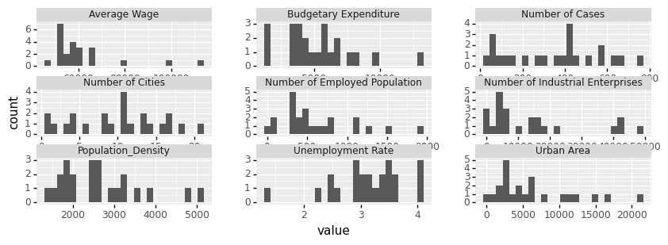

We consider annual GRP as a dependent variable, number of industrial enterprises, average wages, budgetary expenditures, population density, urban area, residence population, number of cities, unemployment rate, number of employed persons, and number of investigations as independent variables. While Figure 6 provides regional economic performance for the short term, it also shows region might be a hidden factor that can cause endogeneity when we consider multivariate regression models in the long run. Thus, besides the abovementioned variables, we created region dummy variables as independent variables to include regional effects in the long-run model, dividing all provinces into six categories and collapsing them to increase bin sizes.

|  | Year | Gross Product | Number of Industrial Enterprises | Average Wage | Budgetary Expenditure | Population_Density | Urban Area | Number of Cities | Unemployment Rate | Population | Number of Employed Population | Number of Cases | North | East | SouthCentral | Southwest | Northwest | Northeast |
| --- | --- | --- | --- | --- | --- | --- | --- | --- | --- | --- | --- | --- | --- | --- | --- | --- | --- | --- |
| 31 | 2015 | 24779.1 | 3548.0 | 111390.0 | 5737.70 | 1541.0 | 12187.0 | 1.0 | 1.4 | 2188 | 777.3 | 64.0 | 1 | 0 | 0 | 0 | 0 | 0 |
| 32 | 2015 | 10879.5 | 5525.0 | 80090.0 | 3232.35 | 3492.0 | 2506.0 | 1.0 | 3.5 | 1439 | 294.8 | 60.0 | 1 | 0 | 0 | 0 | 0 | 0 |
| 33 | 2015 | 26398.4 | 15295.0 | 50921.0 | 5632.19 | 2646.0 | 6399.0 | 11.0 | 3.6 | 7345 | 643.6 | 266.0 | 1 | 0 | 0 | 0 | 0 | 0 |
| 34 | 2015 | 11836.4 | 3845.0 | 51803.0 | 3422.97 | 3920.0 | 2837.0 | 11.0 | 3.5 | 3519 | 440.3 | 409.0 | 1 | 0 | 0 | 0 | 0 | 0 |
| 35 | 2015 | 12949.0 | 4404.0 | 57135.0 | 4252.96 | 1629.0 | 5373.0 | 9.0 | 3.6 | 2440 | 298.3 | 137.0 | 1 | 0 | 0 | 0 | 0 | 0 |

To get the model with the best performance, we went through model tuning and put them all together in the grid search with negative mean squared error as scoring standard. After obtaining the model with the best performance, we will further permute the features to determine measures of the increase in the model's prediction error after we permute the feature's values and look at the partial dependency of GRP on the most important variables.

### Result

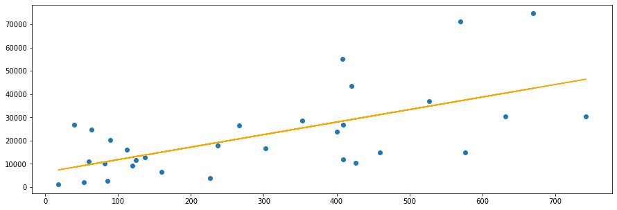

OLS Regression Results

| Dep. Variable: | y | R-squared: | 0.392 |
| --- | --- | --- | --- |
| Model: | OLS | Adj. R-squared: | 0.371 |
| Method: | Least Squares | F-statistic: | 18.71 |
| Date: | Wed, 01 Dec 2021 | Prob (F-statistic): | 0.000165 |
| Time: | 16:01:44 | Log-Likelihood: | -340.07 |
| No. Observations: | 31 | AIC: | 684.1 |
| Df Residuals: | 29 | BIC: | 687.0 |
| Df Model: | 1 |  |  |
| Covariance Type: | nonrobust |  |  |

|  | coef | std err | t | P>\|t\| | [0.025 | 0.975] |
| --- | --- | --- | --- | --- | --- | --- |
| Intercept | 6424.8465 | 4518.857 | 1.422 | 0.166 | -2817.253 | 1.57e+04 |
| x | 53.8875 | 12.460 | 4.325 | 0.000 | 28.405 | 79.370 |

| Omnibus: | 4.336 | Durbin-Watson: | 1.535 |
| --- | --- | --- | --- |
| Prob(Omnibus): | 0.114 | Jarque-Bera (JB): | 3.265 |
| Skew: | 0.790 | Prob(JB): | 0.195 |
| Kurtosis: | 3.170 | Cond. No. | 628. |

Notes:  
[1] Standard Errors assume that the covariance matrix of the errors is correctly specified.

|  | variable | vi | std | low | high |
| --- | --- | --- | --- | --- | --- |
| 0 | Number of Employed Population | 0.594474 | 0.131452 | 0.331570 | 0.857378 |
| 1 | Number of Industrial Enterprises | 0.166778 | 0.039476 | 0.087827 | 0.245729 |
| 2 | Budgetary Expenditure | 0.128048 | 0.025737 | 0.076573 | 0.179523 |
| 3 | Population | 0.092964 | 0.019174 | 0.054616 | 0.131311 |
| 4 | Urban Area | 0.015190 | 0.004163 | 0.006865 | 0.023515 |
| 5 | SouthCentral | 0.004434 | 0.001476 | 0.001481 | 0.007386 |
| 6 | Unemployment Rate | 0.003577 | 0.001327 | 0.000923 | 0.006232 |
| 7 | Northeast | 0.002086 | 0.001094 | -0.000102 | 0.004275 |
| 8 | East | 0.000587 | 0.000593 | -0.000598 | 0.001773 |
| 9 | Average Wage | 0.000551 | 0.000593 | -0.000634 | 0.001737 |
| 10 | North | 0.000427 | 0.000493 | -0.000559 | 0.001412 |
| 11 | Number of Cities | 0.000293 | 0.000318 | -0.000344 | 0.000930 |
| 12 | Population_Density | 0.000274 | 0.000340 | -0.000406 | 0.000953 |
| 13 | Number of Cases | 0.000071 | 0.000172 | -0.000273 | 0.000415 |
| 14 | Southwest | 0.000053 | 0.000193 | -0.000333 | 0.000438 |
| 15 | Northwest | 0.000028 | 0.000090 | -0.000152 | 0.000208 |
| 16 | Year | 0.000000 | 0.000000 | 0.000000 | 0.000000 |

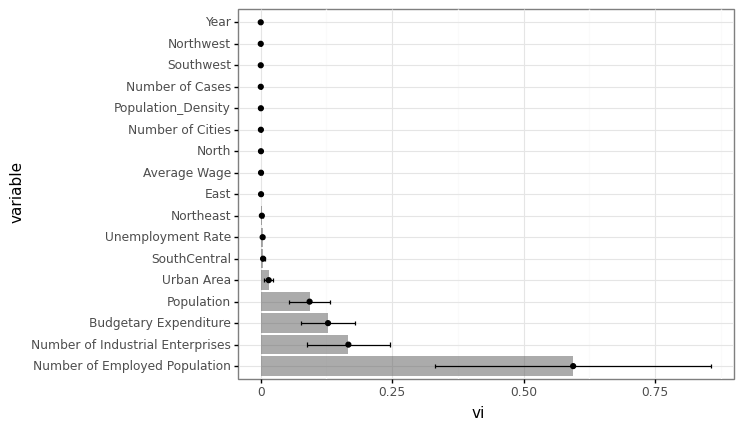

Permutation dependency indicates that Number of employed population, number of industrial enterprises, budgetary expenditures, and population are four variables the model mostly relies on. Notably, the number of invested cases is not considered as an important variable in this model. The partial dependency further explains the relationship between dependent and independent variables. From the partial dependency plot, we see a positive linear relationship between the number of employed population, number of industrial enterprises, and budgetary expenditures, indicating an increase in those variables also leads to an increase in GRP. Furthermore, the linear regression line between number of employed population and GRP is sharper, indicating the number of employed population exerts a larger effect on GRP. The linear regression line for population and GRP has a negative slope, showing an increase in population leads to a decrease in GRP.

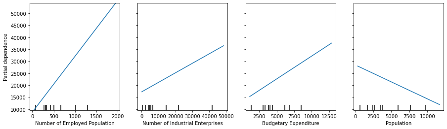

The ICE plot gives an in-depth look for the dependent variable’s dependency on each unit of data. Most observations for these four variables have the same trend of sloping.

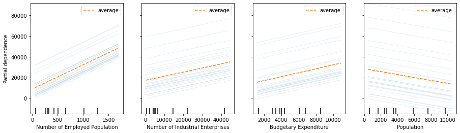

### Discussion

Based on the analysis conducted above, this paper concludes that, in the short run, mainly when most corruption cases are investigated and officials are removed, the economic performance in the specific region will be positively stimulated by the shock. However, in the long run, China’s economic performance relies primarily on how many people are employed and the development of industrial enterprises, governmental budgetary expenditures, and population. This observation further explains CCP’s decision to mobilize the campaign, which strengthened their legitimacy through the massive performance. While in the short term, the anti-corruption campaign may not harm the economy, which is one fundamental pillar to CCP’s performance-based legitimacy, China’s economic performance cannot be fully explained by the political movement. Even with chronic purge within the party, the CCP still faces challenges from multiple areas, such as employment, development of industrial enterprises, governmental budgetary expenditure, and population, in maintaining a promising economic outlook.

This project provides a clear outlook of how the momentum of the anti-corruption campaign is different in different regions, periods in China. Furthermore, it explains whether the campaign impacts economic performance and its importance in both the short run and long run. Using the same dataset, one could also conduct time-series analysis further to understand the effect in a specific time lag. Personally, I would expand the data on corruption investigations and economic variables by specifying them to the county level and for a more comprehensive time range (after 2016).

### Work Cited

Alesina, A., Özler, S., Roubini, N., & Swagel, P. (1996). Political instability and economic growth. Journal Of Economic Growth, 1(2), 189-211. doi: 10.1007/bf00138862

Barreda, D. M., Jakes, S., Laha, M., & Segal-Williams, S. (2018, August 15). Visualizing China's anti-corruption campaign. Retrieved December 15, 2021, from https://www.chinafile.com/infographics/visualizing-chinas-anti-corruption-campaign

du Boulay, S. (2019). Why Authoritarian Legitimation Matters?. Retrieved 30 November 2021, from http://caspianet.eu/2019/01/10/why-authoritarian-legitimation-matters/

Economist Intelligence Unit. (2015, May 14). Local government shakedown leaves its mark. Retrieved December 15, 2021, from http://country.eiu.com/article.aspx?articleid=294852413&Country=China&topic=Economy&oid=1733180957&flid=2023154186

Li, Cheng. (2010). “China's Communist Party-State: The Structure and Dynamics of Power.” Politics In China: An Introduction, Oxford University Press , pp. 166–167.

Luo, P. (2015, March 06). 江西省委书记强卫：苏荣腐败损害江西的政治生态. Retrieved December 15, 2021, from https://www.chinanews.com.cn/gn/2015/03-06/7105545.shtml

Mertha, A. (2005). China's “Soft” Centralization: Shifting Tiao/Kuai Authority Relations. The China Quarterly, 184, 791-810. doi: 10.1017/s0305741005000500

Roskin, M. G. (2016). Countries and concepts: Politics, geography, culture. Boston: Pearson.

Standardization Administration of China. (2021). Codes for the administrative divisions of the People's Republic of China. Retrieved December 15, 2021, from http://www.gb688.cn/bzgk/gb/newGbInfo?hcno=C9C488FD717AFDCD52157F41C3302C6D

State Council of the People's Republic of China. (2014, August 26). Administrative Division. Retrieved December 15, 2021, from http://english.www.gov.cn/archive/china_abc/2014/08/27/content_281474983873401.htm

Wang, Y., & Dickson, B. (2020). How Corruption Investigations Undermine Regime Support: Evidence from China. SSRN Electronic Journal. doi: 10.2139/ssrn.3086286

Zuo, M. (2014, December 23). Ling Jihua 'to face same fate as Bo Xilai'. Retrieved December 15, 2021, from https://www.scmp.com/news/china/article/1668570/ling-jihua-face-same-fate-bo-xilai

### Data Resource

Wang,Yuhua, 2020, "China’s Corruption Investigations Dataset", https://doi.org/10.7910/DVN/9QZRAD, Harvard Dataverse, V4, UNF:6:pt1h9LKzO0aD6F30y7KQGg== [fileUNF]

National Bureau of Statistics of China. (2019). Annual Data by Province [Data file and code book]. Retrieved from https://data.stats.gov.cn/english/easyquery.htm?cn=E0103

[output not shown]